# Multi-Cohort Transcriptomic Stratification and Target Safety Profiling in Renal Cell Carcinoma

- Show All Code
- Hide All Code
- View Source

Cross-Analysis of TCGA Malignancy and GTEx Healthy Baseline Tissue Frameworks

Author

Ankita T. Kandalkar

Published

June 28, 2026

# 1 Executive Summary & Background

This investigative workflow establishes a multi-cohort transcriptomic analysis framework to characterize intermediate molecular phenotypes in Renal Cell Carcinoma (RCC). By leveraging patient tissue data from The Cancer Genome Atlas (TCGA) alongside normal baseline matrices from the Genotype-Tissue Expression (GTEx) portal, I aim to map trans-hierarchical clusters that display intermediate or mixed features spanning Clear Cell (KIRC) and Papillary (KIRP) RCC lineages. Identifying these atypical patient subsets provides vital insights into patient stratification, disease progression modeling, and robust safety filtering for novel therapeutic drug targets.

The foundational biomarker signature utilized in this study is adapted from *Büttner et al. (2022) Genome Medicine* (DOI: 10.1186/s13073-022-01105-y), comprising a curated cohort panel of 174 subtype-specific genes.

# 2 Computational Environment & Library Initialization

I utilize core Bioconductor packages alongside data manipulation and data visualization frameworks to ensure a reproducible, production-grade pipeline.

```r
# Load downstream differential expression, matrix manipulation, and plotting frameworks
library(tidyr)
library(tidyr)
library(dplyr)
library(ggplot2)
library(ggrepel)
library(patchwork)
library(scales)
library(ComplexHeatmap)
library(EnhancedVolcano)
library(DESeq2)

# Set global seed for reproducible clustering and visualization layout
set.seed(42)
```

# 3 Modular Utility Custom Functions

To maintain modularity and clear maintainability, I encapsulated the visualization functions below.

```r
# Custom wrapper for Principal Component Analysis computation and standard theme plotting
plot_pca <- function(data, meta, color, size = 1.2, alpha = 0.6) {

  # prcomp operates on rows; transposing matrix ensure variance is calculated across samples/patients
  pca_res <- prcomp(t(data), center = TRUE, scale = FALSE)

  # Compute eigen-contribution per component to track captured biological variance
  explained_variance <- pca_res$sdev^2 / sum(pca_res$sdev^2) * 100

  df_pc <- data.frame(PC1 = pca_res$x[, 1], PC2 = pca_res$x[, 2], meta)

  ggplot(df_pc, aes(x = PC1, y = PC2, color = .data[[color]])) +
    geom_point(size = size, alpha = alpha) +
    theme_classic() +
    scale_color_brewer(palette = "Set1") +
    labs(
      x = paste0("PC1: ", round(explained_variance[1], 1), "% variance"),
      y = paste0("PC2: ", round(explained_variance[2], 1), "% variance"),
      title = paste("Dimensionality Reduction Mapping by", color)
    ) +
    theme(plot.title = element_text(face = "bold", size = 11))
}

# Multi-panel visualization function to map explicit target genes against computed PCA coordinates
plot_selected_genes <- function(vsd, meta, genes_for_pca, genes_to_plot, size = 1) {
  pca_res <- prcomp(t(assay(vsd)[genes_for_pca,]), center = TRUE, scale = FALSE)
  df_pca <- data.frame(PC1 = pca_res$x[, 1], PC2 = pca_res$x[, 2], meta)
  explained_variance <- pca_res$sdev^2 / sum(pca_res$sdev^2) * 100

  # Extract normalized VST values for targeted safety-marker candidates
  genes_to_plot_vsd <- data.frame(t(assay(vsd)[genes_to_plot, ]))
  df_genes_long <- data.frame(genes_to_plot_vsd, df_pca[, c("PC1", "PC2")])

  # Reshape to long format to enable clean multi-panel facet wrapping via ggplot2
  df_long <- pivot_longer(
    df_genes_long,
    cols = all_of(genes_to_plot),
    names_to = "Gene",
    values_to = "Expression"
  )

  ggplot(df_long, aes(x = PC1, y = PC2, color = Expression)) +
    geom_point(size = size, alpha = 0.5) +
    scale_color_gradient(low = "blue", high = "red") +
    theme_classic() +
    labs(
      x = paste0("PC1: ", round(explained_variance[1], 1), "% variance"),
      y = paste0("PC2: ", round(explained_variance[2], 1), "% variance"),
      color = "Expression (VST)"
    ) +
    facet_wrap(~ Gene)
}
```

# 4 Reference Subtype Signature Gene Arrays

Gene signatures derived from Table S4 of Büttner et al. (2022) characterizing stable lineages:

```r
# Subtype-specific biomarker arrays verified via Büttner cross-validation cohorts
ccRCC_genes <- c("CP", "LOX", "EGLN3", "CYP2J2", "CDR1", "NDUFA4L2", "ANGPTL4", "SLC5A12", "FRZB", "GSTA1", "DNAH11", "SLC17A4", "PLN", "PLCB1", "HILPDA", "ABCC2", "A1CF", "SERPINE1", "SLC2A3", "GBP4", "MME", "F8", "FMO2", "CALCRL", "UGT1A6", "KMO", "FHL5", "ST8SIA4", "SLC2A1", "PREX2", "IGFBP3", "ALDOC", "PDK4", "CDH11", "INHBB", "EDN1", "TMEM45A", "SLC6A3", "GIMAP7", "IFI44L", "HEG1", "P4HA1", "GIMAP4", "ETS1", "LHFPL6", "IFITM1", "ARRDC3", "CA9", "SLC2A5", "BNIP3", "ITGA5", "SLC39A14", "DEPP1", "LAMA4", "PHKA2", "TCF4", "PDE3A", "A2M")

pRCC_genes <- c("LRRN4", "SLPI", "SLC34A2", "PROM1", "RELN", "SOSTDC1", "PIGR", "CNTN6", "SLC44A4", "UPK1B", "RBP4", "CLDN3", "MMP7", "TSPAN1", "CLIC6", "SLC6A20", "BAMBI", "IL12RB2", "MACC1", "CXCL6", "GPC4", "PTPRD", "IGFBP6", "LAMC2", "GALNT11", "TMEM139", "PAPPA", "HUNK", "SOX9", "AIF1L", "CDHR2", "PRICKLE1", "SOX4", "PCLO", "IL17RD", "MYL3", "C17orf97", "ADCY2", "PTH1R", "PGGHG", "ADGRA3", "ELF3", "LCN2", "TMEM163", "LAMB1", "FAM189A1", "SCARA3", "B3GALT5", "PAX2", "SLC15A2", "HYDIN", "FOXQ1", "AK7", "PLXNB1", "DCBLD2", "C21orf62", "NAPEPLD", "CNTN4")

chRCC_genes <- c("ATP6V0D2", "SLC26A7", "PVALB", "STAP1", "CFTR", "HEPACAM2", "ERP27", "CLNK", "RHCG", "CLDN8", "ATP6V1G3", "FOXI1", "ATP6V1C2", "SHOC1", "TMEM52B", "TMEM213", "BMPR1B", "MUC20", "SLC4A1", "TMPRSS2", "MYZAP", "ATP6V1B1", "CWH43", "EGF", "CKMT2", "GRB14", "GPRC6A", "SEMA3C", "SLC16A7", "SLC9A2", "CNTNAP5", "KLK1", "OXGR1", "NEDD4L", "PRLR", "HS6ST3", "SLC2A12", "DHRS7", "FYB2", "TMEM255A", "DMRT2", "GPAT3", "THRSP", "FXYD4", "STK32A", "RANBP3L", "FAM169A", "SYT17", "KLHL3", "TBC1D14", "UGT8", "PXK", "WNK3", "GALNT17", "PACRG", "IL18", "PKIA", "ANGPTL1")

# Consolidate vectors into a master feature array for downstream matrix filtering
master_signature <- unique(c(ccRCC_genes, pRCC_genes, chRCC_genes))
```

# 5 Data Ingestion & Transformation Pipelines

I ingest the primary quantification tables and perform an arithmetic inverse log transformation to restore counts to pure integer vectors as required by negative binomial distributions in `DESeq2`.

```r
# Ingest clinical expression matrix and patient covariate tables
tcga_counts_kidney <- read.csv("/cloud/project/outs/3_tcga_counts_subset.csv", sep = ",", row.names = 1, header = TRUE)
tcga_meta_kidney <- read.csv("/cloud/project/outs/3_tcga_meta_subset.csv", sep = ",", header = TRUE)

# Reverse log2(counts + 1) transform; ceiling() generates true un-logged integer vectors required by DESeq2's GLMs
tcga_counts_kidney <- ceiling(2^(tcga_counts_kidney) - 1)

# Defensive execution assertions to guarantee valid data input distributions
stopifnot(sum(is.na(tcga_counts_kidney)) == 0)
stopifnot(min(tcga_counts_kidney) >= 0)
```

# 6 Primary Unsupervised Subtype Stratification

I initiate a variance-stabilizing transformation (`vst`) to execute unsupervised hierarchical clustering across the intersection panel of signature genes.

```r
# Build formal DESeq object linking expression raw vectors to histological annotations
tcga_dds <- DESeqDataSetFromMatrix(
  countData = data.frame(tcga_counts_kidney),
  colData = tcga_meta_kidney,
  design = ~ cancer.type.abbreviation
)

# Apply low-abundance threshold filter to improve statistical testing performance
tcga_dds <- tcga_dds[rowSums(counts(tcga_dds)) >= 100, ]

# Apply variance stabilizing transformation to homoscedasticize low-count count-variance relationships
tcga_vsd <- vst(tcga_dds, blind = FALSE)

# Extract only signature features that passed filtering and run agglomerative clustering using Euclidean distance
kidney_cancer_subtype_genes <- intersect(master_signature, rownames(assay(tcga_vsd)))
sample_dist <- dist(t(assay(tcga_vsd)[kidney_cancer_subtype_genes, ]))
hc <- hclust(sample_dist, method = "complete")

# Partition the cohort distance tree into exactly 4 logical spatial groupings
tcga_meta_kidney$Cluster <- factor(cutree(hc, k = 4))
```

## 6.1 Dimensional Reduction Profiling

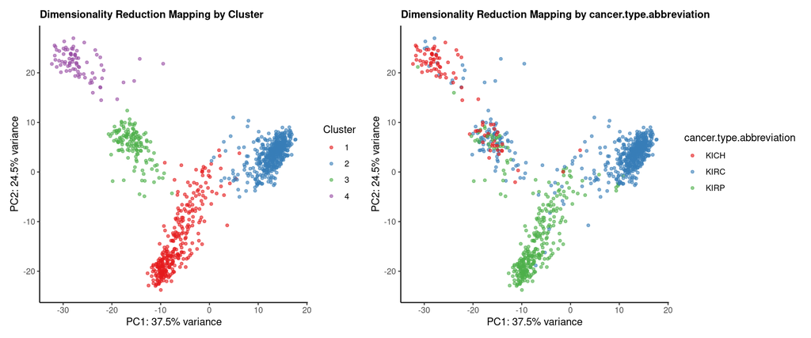

```r
# Contrast unsupervised statistical clusters side-by-side with official pathological classifications
p1 <- plot_pca(assay(tcga_vsd)[kidney_cancer_subtype_genes, ], tcga_meta_kidney, "Cluster")
p2 <- plot_pca(assay(tcga_vsd)[kidney_cancer_subtype_genes, ], tcga_meta_kidney, "cancer.type.abbreviation")
p1 + p2
```

## 6.2 Differential Expression Modeling of the Mixed Phenotype

```r
# Isolate the trans-hierarchical cluster population vs all stable subtype controls
tcga_meta_kidney$Phenotype_Status <- ifelse(tcga_meta_kidney$Cluster == "3", "Mixed_Phenotype", "Stable_Subtype")
tcga_meta_kidney$Phenotype_Status <- factor(tcga_meta_kidney$Phenotype_Status, levels = c("Stable_Subtype", "Mixed_Phenotype"))

# Re-initialize generalized linear model to test our specific group comparison
dds_pipeline <- DESeqDataSetFromMatrix(
  countData = data.frame(tcga_counts_kidney),
  colData = tcga_meta_kidney,
  design = ~ Phenotype_Status
)
dds_pipeline <- dds_pipeline[rowSums(counts(dds_pipeline)) >= 100, ]

# Execute empirical Bayes dispersion estimation and fit negative binomial GLM via Wald test
dds_pipeline <- DESeq(dds_pipeline)

# Extract contrast metrics specifically examining the expression drift of the mixed phenotype
res_mixed <- results(dds_pipeline, contrast = c("Phenotype_Status", "Mixed_Phenotype", "Stable_Subtype"))

# Order by adjusted p-value to maximize data-significance sorting
res_reordered <- res_mixed %>%
  as.data.frame() %>%
  tibble::rownames_to_column(var = "gene_symbol") %>%
  filter(!is.na(padj)) %>%
  arrange(padj)

# Filter out high-confidence transcriptomic drivers for safety review formatting
top_degs_up <- res_reordered %>% filter(log2FoldChange > 1.5, padj < 0.01) %>% head(10)
top_degs_down <- res_reordered %>% filter(log2FoldChange < -1.5, padj < 0.01) %>% head(10)
target_labels <- c(top_degs_up$gene_symbol, top_degs_down$gene_symbol)
```

## 6.3 Transcriptomic Volcanoplot Communication

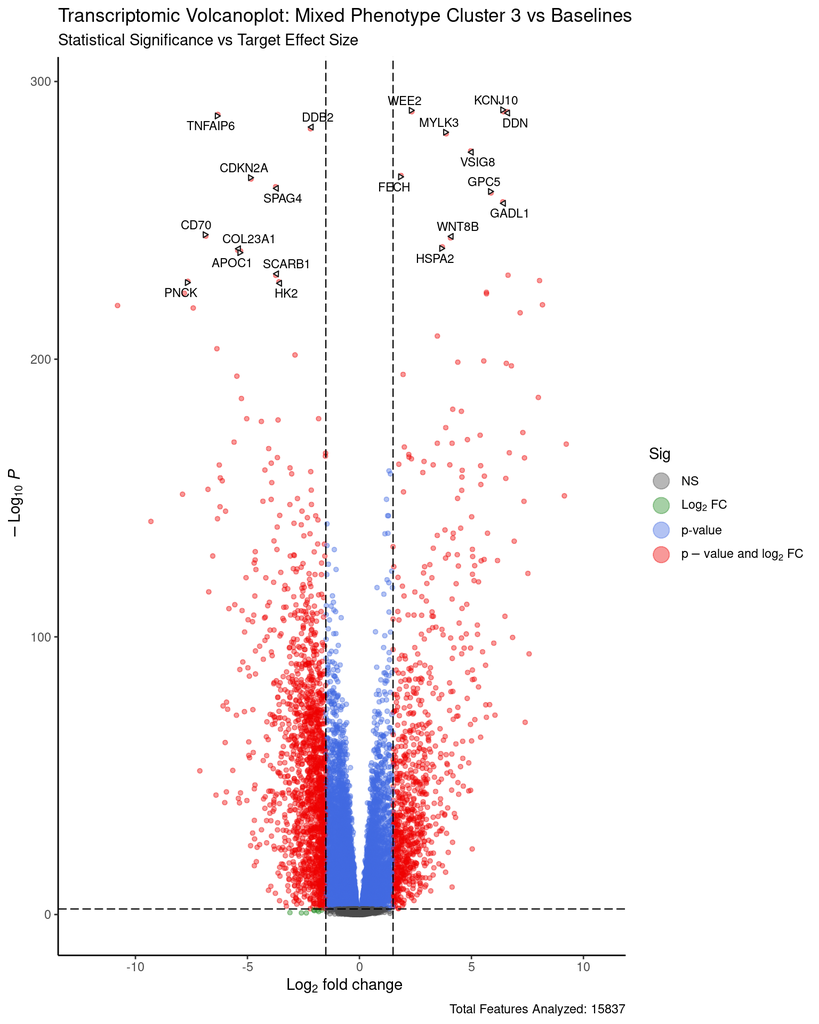

```r
# Visualize complete differential expression distribution topology and label key target features
EnhancedVolcano(
  res_reordered,
  x = "log2FoldChange",
  y = "padj",
  lab = res_reordered$gene_symbol,
  selectLab = target_labels,
  pCutoff = 0.01,
  FCcutoff = 1.5,
  labSize = 3,
  title = "Transcriptomic Volcanoplot: Mixed Phenotype Cluster 3 vs Baselines",
  subtitle = "Statistical Significance vs Target Effect Size",
  caption = paste("Total Features Analyzed:", nrow(res_reordered)),
  pointSize = 1.2,
  colAlpha = 0.4,
  drawConnectors = TRUE,
  widthConnectors = 0.4,
  max.overlaps = 15
) + theme_classic()
```

# 7 Cross-Cohort Normal Tissue Filtering & Target Safety Assessment

To ensure candidate genes discovered in the mixed phenotype cluster do not serve critical functions in normal organs (which could drive lethal on-target/off-tumor toxicity profiles in preclinical drug validation), I developed a secondary pipeline using the corresponding GTEx healthy baseline files.

```r
library(data.table)
library(R.utils)

# Ingest Sample Metadata annotations via fast-parsing data.table framework
gtex_meta <- fread("/cloud/project/data/gtex/GTEx_Analysis_v10_Annotations_SampleAttributesDS.txt", sep = "\t", header = TRUE)

# Filter for Kidney samples to isolate base tissue controls
gtex_kidney_samples <- gtex_meta %>%
  filter(SMTS == "Kidney") %>%
  pull(SAMPID)

# Extract Top Up-regulated candidates from the Cluster 3 signature to filter for safety windows
potential_biomarkers <- res_reordered %>%
  filter(padj < 0.001, log2FoldChange > 2.0) %>%
  slice_min(order_by = padj, n = 5) %>%
  pull(gene_symbol)

# Stream-parse multi-gigabyte compressed GCT expression matrix bypassing memory bloat
gtex_counts <- fread(
  "/cloud/project/data/gtex/GTEx_Analysis_v10_RNASeQCv2.4.2_gene_reads.gct.gz",
  skip = 2,
  header = TRUE
)

setnames(gtex_counts, "Description", "gene_symbol")

# Execute row-filtering to instantly drop non-biomarker rows from active working memory
biomarker_gtex_matrix <- gtex_counts %>%
  filter(gene_symbol %in% potential_biomarkers)

# Pivot data into long-format to execute grouped joins with tissue location attributes
gtex_meta_lookup <- gtex_meta %>% select(SAMPID, SMTS, SMTSD)

biomarker_safety_df <- biomarker_gtex_matrix %>%
  select(-Name) %>%
  pivot_longer(cols = -gene_symbol, names_to = "SAMPID", values_to = "Raw_Counts") %>%
  inner_join(gtex_meta_lookup, by = "SAMPID")

# Calculate vital organ baseline median values to map potential off-tumor toxicity liabilities
safety_summary <- biomarker_safety_df %>%
  group_by(gene_symbol, SMTS) %>%
  summarize(
    Median_Expression = median(Raw_Counts, na.rm = TRUE),
    Max_Expression = max(Raw_Counts, na.rm = TRUE),
    .groups = "drop"
  ) %>%
  arrange(gene_symbol, desc(Median_Expression))

print("Automated Cohort Safety Review: Top Candidate Biomarker Profiling across GTEx Baseline:")
```

```
[1] "Automated Cohort Safety Review: Top Candidate Biomarker Profiling across GTEx Baseline:"
```

```r
print(head(safety_summary, 20))
```

```
# A tibble: 20 × 4
   gene_symbol SMTS            Median_Expression Max_Expression
   <chr>       <chr>                       <dbl>          <int>
 1 DDN         Muscle                    15901           344661
 2 DDN         Brain                     10386           143457
 3 DDN         Kidney                     2111            12411
 4 DDN         Pituitary                    78              590
 5 DDN         Heart                        52             1048
 6 DDN         Testis                       44              205
 7 DDN         Spleen                       38             1539
 8 DDN         Salivary Gland               35            20566
 9 DDN         Stomach                      27              347
10 DDN         Skin                         25             1928
11 DDN         Small Intestine              20              322
12 DDN         Adrenal Gland                19              163
13 DDN         Blood                        19             2698
14 DDN         Adipose Tissue               16             2543
15 DDN         Blood Vessel                 16             2205
16 DDN         Esophagus                    16             6057
17 DDN         Lung                         15              349
18 DDN         Breast                       13              923
19 DDN         Nerve                        12             1315
20 DDN         Vagina                       11.5             97
```

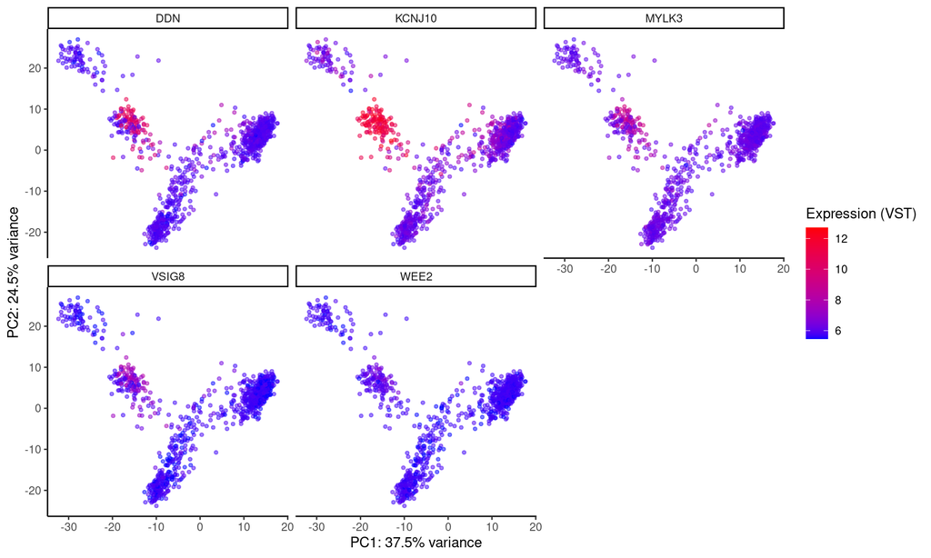

```r
# Safe visualization plot verification check to ensure clear rendering output without crashing session
tryCatch({
  plot_selected_genes(
    vsd = tcga_vsd,
    meta = tcga_meta_kidney,
    genes_for_pca = kidney_cancer_subtype_genes,
    genes_to_plot = intersect(potential_biomarkers, rownames(assay(tcga_vsd)))
  )
}, error = function(e) {
  cat("Dynamic validation plot visualization fallback active:", e$message, "\n")
})
```